# Ismerkedés az R-rel

Tajti András - Tóth Tímea

2018 február 5.

## R? Rstudio? Mik ezek és mi a különbség?

“R is a free software environment for statistical computing and graphics.” Statisztikusok számára készült programozási nyelv, az alap statisztikai függvények a frissen telepített R környezetben elérhetőek:

[figure not shown]

Nyers R konzol

Az r-project.ork-ról letölthető R-rel viszont nehéz dolgozni. Sok kódolást segítő környezet (IDE) létezik, ezeket is lehet használni, az RStudio azonban kifejezetten az R köré épült, rengeteg R-specifikus segítséggel és kiegészítő funcióval:

[figure not shown]

Rstudio felület

A kódolást segítő funciók között van az instant help, az automatikus kódformázás, szintaktikai elenőrzés, Markdown dokumentumok fordítása, Shiny alkalmazások fejlesztésének segítése, stb.

## Hogyan és mire lehet használni?

### Alapműveletek, logikai műveletek elvégzésére:

```r
1 < 2
```

```
## [1] TRUE
```

```r
1 > 2
```

```
## [1] FALSE
```

```r
1 == 2
```

```
## [1] FALSE
```

```r
1 + 1
```

```
## [1] 2
```

```r
1 : 4
```

```
## [1] 1 2 3 4
```

```r
2 ^ 2
```

```
## [1] 4
```

```r
1 / 4
```

```
## [1] 0.25
```

```r
1:4 / 4
```

```
## [1] 0.25 0.50 0.75 1.00
```

```r
1:4 / 2:1
```

```
## [1] 0.5 2.0 1.5 4.0
```

### Különböző adatok és eredmények tárolására:

```r
szam <- 1
szam
```

```
## [1] 1
```

```r
betu <- "b"
betu
```

```
## [1] "b"
```

```r
vektor <- 1:4
vektor
```

```
## [1] 1 2 3 4
```

```r
mat <- matrix(1:9, nrow=3)
mat
```

```
##      [,1] [,2] [,3]
## [1,]    1    4    7
## [2,]    2    5    8
## [3,]    3    6    9
```

```r
fact <- factor(c("Község", "Város", "Megyeszékhely", "Város", "Város"))
fact
```

```
## [1] Község        Város         Megyeszékhely Város         Város
## Levels: Község Megyeszékhely Város
```

```r
egyszeru_fuggveny <- function(){1}
egyszeru_fuggveny
```

```
## function(){1}
```

```r
egyszeru_fuggveny()
```

```
## [1] 1
```

```r
negyzet_fuggveny <- function(x){x^2}
negyzet_fuggveny(2)
```

```
## [1] 4
```

```r
osszevont_vektor <- c(b=betu, sz=szam, f=fact)
str(osszevont_vektor)
```

```
##  Named chr [1:7] "b" "1" "1" "3" "2" "3" "3"
##  - attr(*, "names")= chr [1:7] "b" "sz" "f1" "f2" ...
```

```r
lista <- list(b=betu, sz=szam, v=vektor, f=negyzet_fuggveny)
str(lista)
```

```
## List of 4
##  $ b : chr "b"
##  $ sz: num 1
##  $ v : int [1:4] 1 2 3 4
##  $ f :function (x)
##   ..- attr(*, "srcref")=Class 'srcref'  atomic [1:8] 20 21 20 36 21 36 20 20
##   .. .. ..- attr(*, "srcfile")=Classes 'srcfilecopy', 'srcfile' <environment: 0x000000000b511fe0>
```

*Feladat: Készítsetek egy vektort, ami megmondja, hogy 1-től 10-ig egy szám páratlan-e, vagy páros!*

```
##  [1] 1 0 1 0 1 0 1 0 1 0
```

*Feladat: írjatok egy függvényt, ami megmondja, hogy egy adott vektorban szereplő értékeknek mekkora a varianciája!*

### Adattáblák létrehozására

Az adatok tárolására az alap R-ben a data.frame nevű objektum szolgál:

```r
adatok <- data.frame(
  id = 1:10,
  szul_ido = sample(x = 1950:2000,
                     size =10),
  telepules_kat = as.factor(sample(
                             x = c("Főváros", "Város", "Község"),
                             size = 10,
                             replace = TRUE,
                             prob = c(2, 4, 4)))
)
adatok$havi_jov <- (2018 - adatok$szul_ido) * 1000 +
                   rnorm(10, 0, 4000)
```

### Véletlen számok generálására:

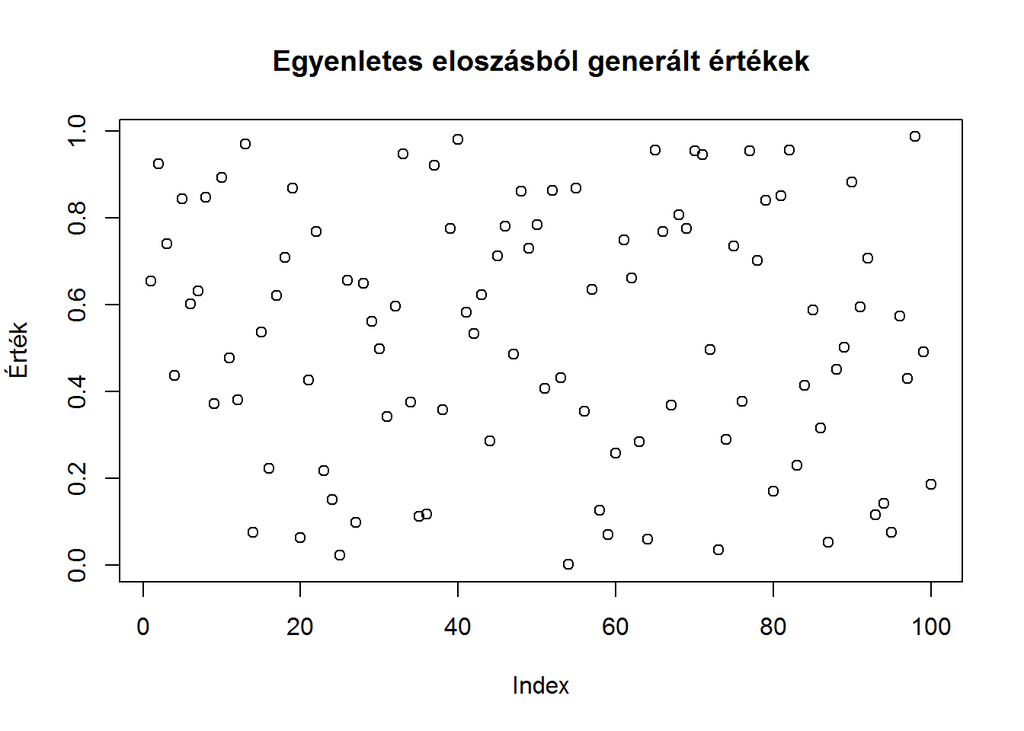

```r
egyenletes_eloszlas <- runif(100)
plot(egyenletes_eloszlas,
     ylab="Érték",
     main="Egyenletes eloszásból generált értékek")
```

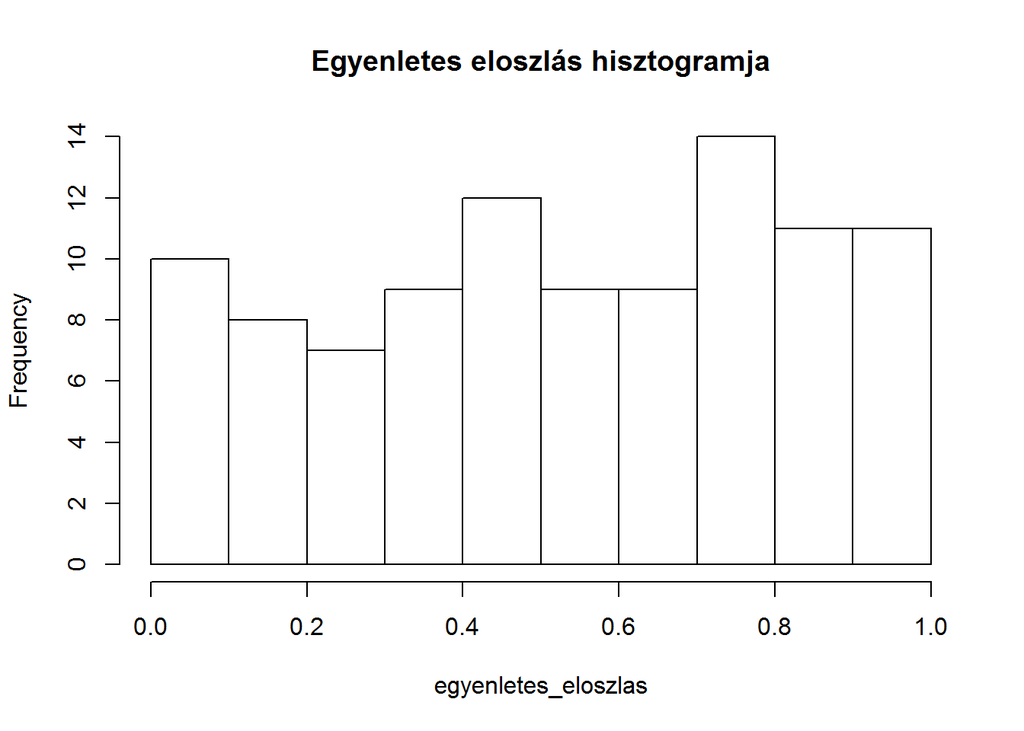

```r
hist(egyenletes_eloszlas,
     main="Egyenletes eloszlás hisztogramja")
```

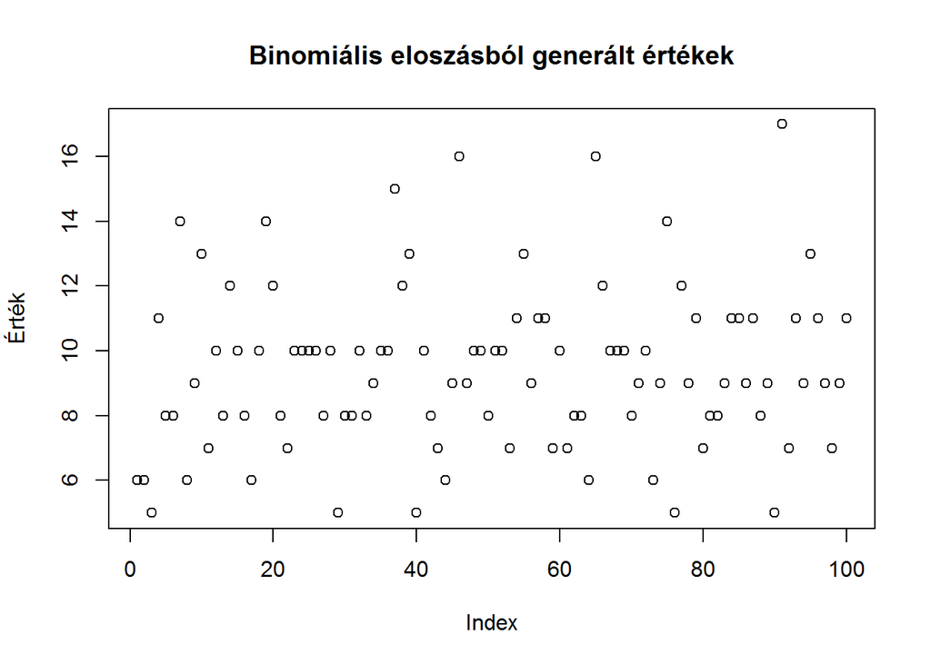

```r
binomialis_eloszlas <- rbinom(100, 60, 1/6)
plot(binomialis_eloszlas,
     ylab="Érték",
     main="Binomiális eloszásból generált értékek")
```

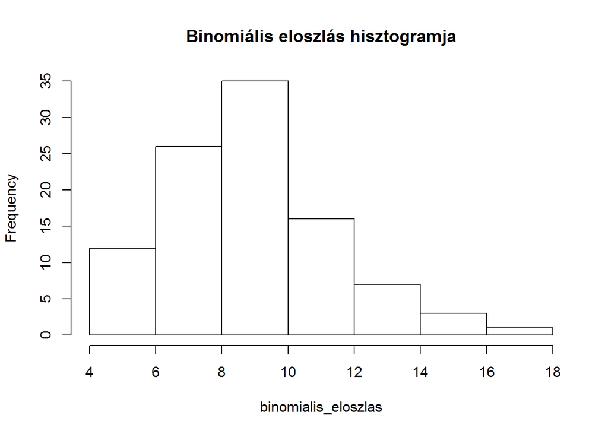

```r
hist(binomialis_eloszlas,
     main="Binomiális eloszlás hisztogramja")
```

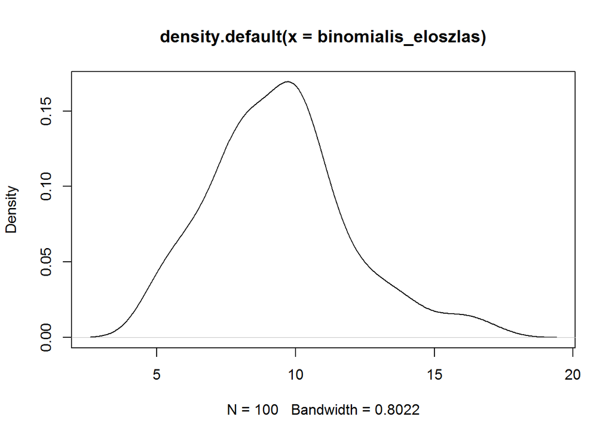

```r
plot(density(binomialis_eloszlas))
```

*Feladat: Nézzétek meg, mekkora egy tetszőleges paraméterekkel generált normáleloszlás átlagának eltérése a várható értékétől! Futtassátok le a függvényt többször, mit tapasztaltok? Módosítsátok a paramétereket, és futtassátok le úgy a függvényt, mire számítunk?*

Ha random számokat generálunk, és azt szeretnénk, hogy az eredményeink reprodukálhatóak legyenek, akkor azt a `set.seed()` függvénnyel érhetjük el, ezzel “rögzítjük” a random szám generálás kezdőpontját.

```r
# Ha beállítjátok azonos értékre a seedet a saját gépeteken, azonos eredményt kell kapnotok
set.seed(123)

mean(rnorm(1000, 50, 20))
```

```
## [1] 50.32256
```

```r
mean(rnorm(1000, 50, 20))
```

```
## [1] 50.84931
```

```r
mean(rnorm(1000, 50, 20))
```

```
## [1] 49.59775
```